# Reproducible research - Assignment week 2

Amelie

23 aout 2017

## Loading and preprocessing the data

Download the data from the internet

```r
url <- "https://d396qusza40orc.cloudfront.net/repdata%2Fdata%2Factivity.zip"
download.file(url, destfile = "activity.zip")
unzip("activity.zip")
```

Preprocess the data

```r
activity <- read.csv("activity.csv")
activity$Date <- as.Date(activity$date, format="%Y-%m-%d")
activity$Date <- as.POSIXct(activity$Date)
```

## What is mean total number of steps taken per day?

```r
library("dplyr")
library("lubridate")
```

Calculate the total number of steps taken a day

```r
sum_steps_day <- activity %>%
  group_by(year = year(Date), month = month(Date), day = day(Date)) %>%
  summarise(sum = sum(steps))
```

Create the histogram

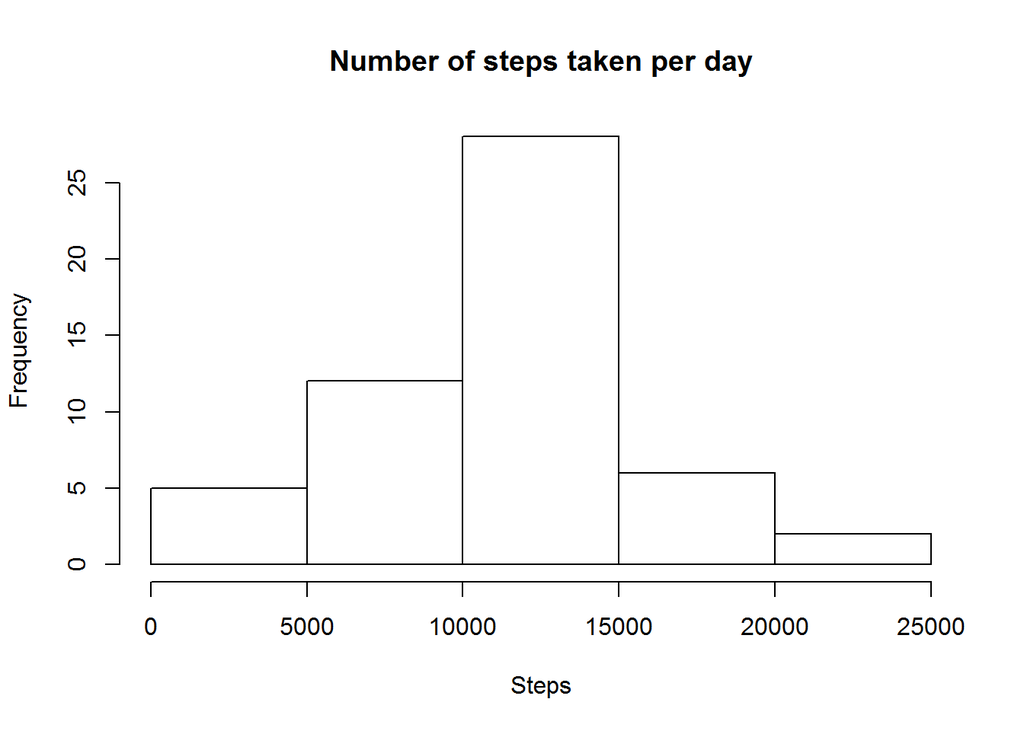

```r
 hist(sum_steps_day$sum, main = "Number of steps taken per day", xlab = "Steps")
```

Calculate the mean total number of steps taken a day

```r
mean_tot_steps_day <- mean(sum_steps_day$sum, na.rm = TRUE)
mean_tot_steps_day
```

```
## [1] 10766.19
```

```r
median_tot_steps_day <- median(sum_steps_day$sum, na.rm = TRUE)
median_tot_steps_day
```

```
## [1] 10765
```

## What is the average daily activity pattern?

Average number of steps taken for all days per 5-minute interval

```r
sum_steps_int <- activity %>%
  group_by(interval = interval) %>%
  summarise(mean = mean(steps, na.rm=TRUE))
```

Create the plot

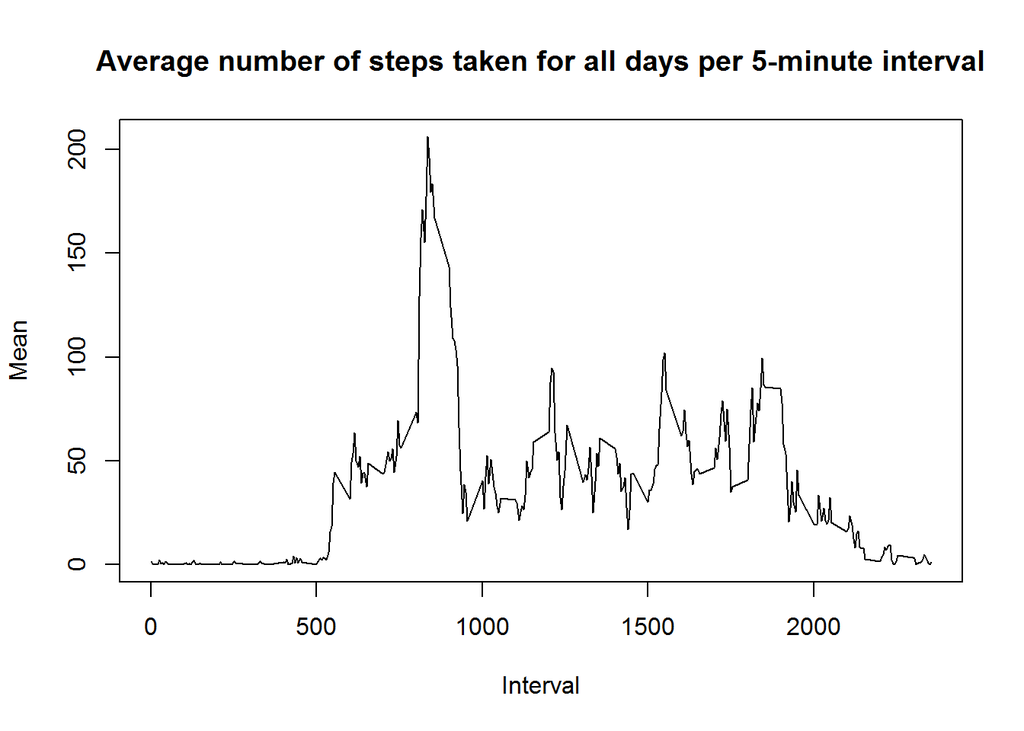

```r
plot(sum_steps_int$interval, sum_steps_int$mean, type="l", ylab = "Mean", xlab = "Interval", main = "Average number of steps taken for all days per 5-minute interval")
```

Which 5-minute interval, on average across all the days in the dataset, contains the maximum number of steps?

```r
sum_steps_int[sum_steps_int$mean==max(sum_steps_int$mean),1]
```

```
## # A tibble: 1 x 1
##   interval
##      <int>
## 1      835
```

## Imputing missing values

Calculate the total number of missing values in the dataset

```r
sum(is.na(activity$steps))
```

```
## [1] 2304
```

Filling missing values in a new dataset

```r
activity_noNA <- read.csv("activity.csv")
activity_noNA$Date <- as.Date(activity_noNA$date, format="%Y-%m-%d")
activity_noNA$Date <- as.POSIXct(activity_noNA$Date)
for(i in 1:nrow(activity_noNA)){
if(is.na(activity_noNA[i,1])){
    int <- activity_noNA[i,3]
    fill <- sum_steps_int[sum_steps_int$interval==int,2]
    activity_noNA[i,1] = fill}}
```

Calculate the total number of steps taken a day including imputed values

```r
sum_steps_day_noNA <- activity_noNA %>%
  group_by(year = year(Date), month = month(Date), day = day(Date)) %>%
  summarise(sum = sum(steps))
```

Create the histogram including imputed values

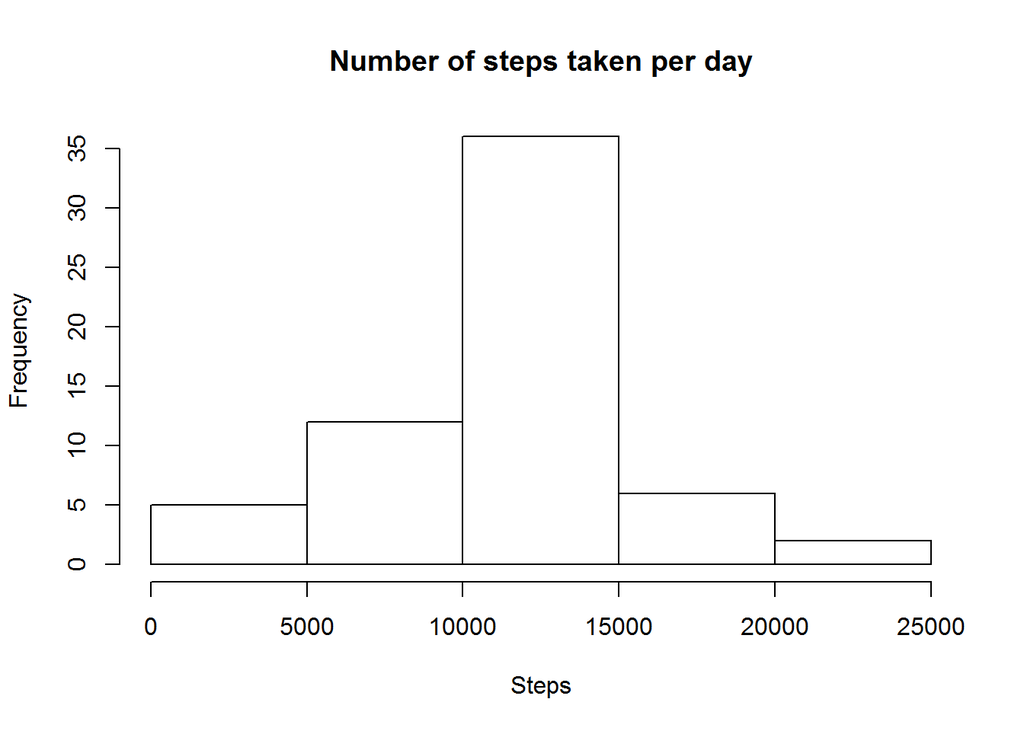

```r
 hist(sum_steps_day_noNA$sum, main = "Number of steps taken per day", xlab = "Steps")
```

Mean of steps taken per day including imputed values

```r
mean_tot_steps_day_noNA <- mean(sum_steps_day_noNA$sum)
mean_tot_steps_day_noNA
```

```
## [1] 10766.19
```

Median of steps taken per day including imputed values

```r
median_tot_steps_day_noNA <- median(sum_steps_day_noNA$sum)
median_tot_steps_day_noNA
```

```
## [1] 10766.19
```

What is the impact of imputing missing data? On the mean: the difference of *data with na* - *data without na* is:

```r
mean_tot_steps_day-mean_tot_steps_day_noNA
```

```
## [1] 0
```

On the media: the difference of *data with na* - *data without na* is:

```r
median_tot_steps_day-median_tot_steps_day_noNA
```

```
## [1] -1.188679
```

## Are there differences in activity patterns between weekdays and weekends?

Add the factor variable

```r
Sys.setlocale("LC_TIME", "English")
```

```
## [1] "English_United States.1252"
```

```r
weekend_list <- c('Saturday', 'Sunday')
activity_noNA$wd_we <- factor((weekdays(activity_noNA$Date) %in% weekend_list),
         levels=c(TRUE, FALSE), labels=c('weekend', 'weekday'))
```

```r
sum_steps_int_wdwe <- activity_noNA %>%
  group_by(interval = interval, wdwe=wd_we) %>%
  summarise(mean = mean(steps))
```

Create the plot

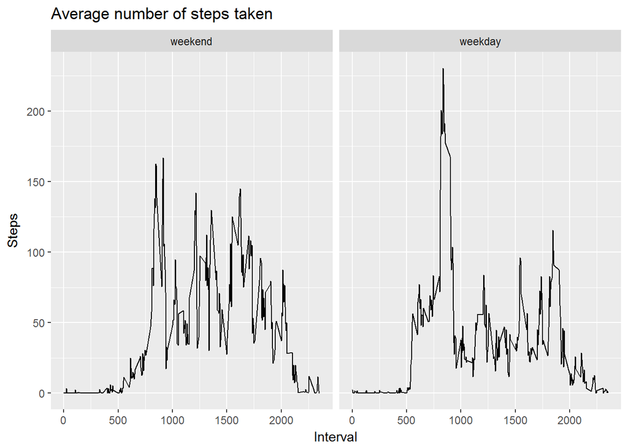

```r
library("ggplot2")
qplot(interval,mean,
      data = sum_steps_int_wdwe,
      facets = .~wdwe,
      geom = "line",
      main = "Average number of steps taken",
      xlab = "Interval",
      ylab = "Steps")
```